# Aprendizaje de redes bayesianas con R

Daniel Ranchal Parrado

26 de febrero de 2022

```r
library(bnlearn)
set.seed(100)
```

# Ejercicio 1

**Como trabajo obligatorio de esta parte de la asignatura, se debe entrgar un script en R y un documento que haga lo siguiente**

1. **Seleccione una red bayesiana con al menos 7 variables. No tiene que ser una red de nueva creación. Puede ser una usada en otras partes de la asignatura o del [repositorio de bnlearn](https://www.bnlearn.com/bnrepository/)**.

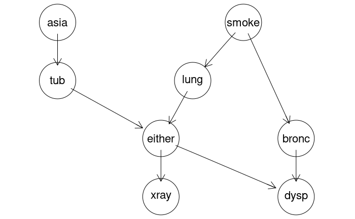

```r
asia_network <- readRDS("asia.rds")
graphviz.plot(asia_network)
```

2. **Simular dos conjuntos de datos de distintos tamaños a partir de la red (por ejemplo uno con 200 casos y otro con 5000 casos).**

Para poder simular conjuntos de datos a partir de la red asia, se ha utilizado la función **rbn**. La función rbn implementa el muestreo lógico probabilístico y permite fijar el número de muestras que queremos generar. En este caso se han generado dos muestras, una con 200 instancias y otra con 5000 instancias.

```r
small_dataset <- rbn(asia_network, n = 200)
big_dataset <- rbn(asia_network, n = 5000)
```

3. **Aprender la estructura con dos métodos distintos, uno basado en test de independencia y otro en scores, y con los dos conjuntos de datos**

En este apartado se ha aprendido la estructura utilizando el conjunto de datos pequeño y grande utilizando métodos basados en test de independencia y en score.

Como método basado en test de independencias se ha utilizado el método growth-shrink. Respecto al método basado en scores que se ha utilizado, se ha usado una búsqueda tabú con el score bde (Bayesian Dirichlet equivalent).

```r
gs.small_dataset.dag <- gs(small_dataset)
gs.small_dataset.dag <- cextend(gs.small_dataset.dag)

gs.big_dataset.dag <- gs(big_dataset)
gs.big_dataset.dag <- cextend(gs.big_dataset.dag)

tabu_search.bde.small_dataset.dag <- tabu(small_dataset, score = "bde")
tabu_search.bde.small_dataset.dag <- cextend(tabu_search.bde.small_dataset.dag)

tabu_search.bde.big_dataset.dag <- tabu(big_dataset, score = "bde")
tabu_search.bde.big_dataset.dag <- cextend(tabu_search.bde.big_dataset.dag)
```

4. **Comparar la estructura de las redes obtenidas con las originales. Comentar las diferencias**

En este apartado se ha comparado la red original con la redes que se han aprendido en la sección anterior. Para ello, se han comparado visualmente con la función **graphviz.compare** y con la métrica de distancia **hamming**. La función **graphviz.compare** recibe como primer argumento la red real y como segundo argumento la red aprendida. La notación visual que utiliza es la siguiente:

- Los arcos que son verdaderos positivos son negros
- Los arcos que son falsos positivos (que no existen o tienen otra dirección en la red original) son rojos
- Los arcos que son falsos negativos son azules.

En el gráfico generado se observan las diferencias entre las distintas redes aprendidas y la red original. Es destacable la diferencia que hay entre los métodos basados en test de independencia y aquellos basados en score. Aquellos basados en score suelen obtener un mayor número de arcos y ser más similares a la red original basándonos en la distancia de hamming. Por otra parte, aquellos basados en test de independencia obtienen una distancia mayor en hamming y por lo tanto, una diferencia muy considerable respecto al anterior método.

Si nos fijamos en las diferencias visuales, cuando se aprende la estructura con un dataset pequeño suele haber un mayor número de falsos negativos, es decir, arcos que faltan respecto a la red original. Por otro lado, con los conjuntos de datos grandes, se suelen cometer más fallos respecto a añadir arcos de más o en una dirección equivocada.

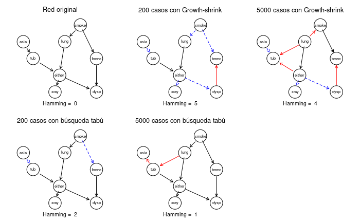

```r
# Just to convert bn.fit object to bn so we can use graphviz.compare function
asia_network_bn <- bn.net(asia_network)

par(mfrow = c(2, 3))
graphviz.compare(
    asia_network_bn,
    gs.small_dataset.dag,
    gs.big_dataset.dag,
    tabu_search.bde.small_dataset.dag,
    tabu_search.bde.big_dataset.dag,
    main = c(
        "Red original",
        "200 casos con Growth-shrink",
        "5000 casos con Growth-shrink",
        "200 casos con búsqueda tabú",
        "5000 casos con búsqueda tabú"
    ),
    sub = paste(
        "Hamming = ",
        c(
            "0",
            hamming(gs.small_dataset.dag, asia_network_bn),
            hamming(gs.big_dataset.dag, asia_network_bn),
            hamming(tabu_search.bde.small_dataset.dag, asia_network_bn),
            hamming(tabu_search.bde.big_dataset.dag, asia_network_bn)
        )
    )
)
```

5. **Aprender los parámetros de las redes**

Finalmente, en esta sección se aprenden los parámetros para cada estructura de red aprendida con su conjunto de datos correspondiente. Para todos los casos, se ha utilizado un procedimiento bayesiano para estimar los parámetros y se ha especificado un tamaño muestral equivalente del 10, que está dentro de la recomendación de fijarlo entre 1 y 15. Mientras más grande sea este tamaño muestral equivalente, la distribuciones a posteriori estimadas tenderán hacia una distribución uniforme.

```r
gs.small_dataset.bayes <- bn.fit(
    gs.small_dataset.dag,
    data = small_dataset,
    method = "bayes",
    iss = 10
)
gs.small_dataset.bayes
```

```
  Bayesian network parameters

  Parameters of node asia (multinomial distribution)

Conditional probability table:
        yes         no
0.03333333 0.96666667

  Parameters of node tub (multinomial distribution)

Conditional probability table:
        yes         no
0.04761905 0.95238095

  Parameters of node smoke (multinomial distribution)

Conditional probability table:
       yes        no
0.5095238 0.4904762

  Parameters of node lung (multinomial distribution)

Conditional probability table:
 yes  no
0.1 0.9

  Parameters of node bronc (multinomial distribution)

Conditional probability table:

     dysp
bronc       yes        no
  yes 0.7783019 0.2163462
  no  0.2216981 0.7836538

  Parameters of node either (multinomial distribution)

Conditional probability table:

, , lung = yes
```

[output cut: 10 more lines]

```
   yes 0.833333333 0.006887052
   no  0.166666667 0.993112948


  Parameters of node xray (multinomial distribution)

Conditional probability table:
      yes       no
0.152381 0.847619

  Parameters of node dysp (multinomial distribution)

Conditional probability table:
       yes        no
0.5047619 0.4952381
```

```r
gs.big_dataset.bayes <- bn.fit(
    gs.big_dataset.dag,
    data = big_dataset,
    method = "bayes",
    iss = 10
)
gs.big_dataset.bayes
```

```
  Bayesian network parameters

  Parameters of node asia (multinomial distribution)

Conditional probability table:
        yes         no
0.01277445 0.98722555

  Parameters of node tub (multinomial distribution)

Conditional probability table:

, , either = yes

     lung
tub            yes           no
  yes 0.0333333333 0.9731182796
  no  0.9666666667 0.0268817204

, , either = no

     lung
tub            yes           no
  yes 0.5000000000 0.0002668944
  no  0.5000000000 0.9997331056


  Parameters of node smoke (multinomial distribution)

Conditional probability table:

     lung
smoke       yes        no
  yes 0.8875000 0.4774841
  no  0.1125000 0.5225159

  Parameters of node lung (multinomial distribution)

Conditional probability table:
        yes         no
```

[output cut: 26 more lines]

```
either         yes          no
   yes 0.991071429 0.009830867
   no  0.008928571 0.990169133

  Parameters of node xray (multinomial distribution)

Conditional probability table:
       yes        no
0.1125749 0.8874251

  Parameters of node dysp (multinomial distribution)

Conditional probability table:
       yes        no
0.4321357 0.5678643
```

```r
tabu_search.bde.small_dataset.bayes <- bn.fit(
    tabu_search.bde.small_dataset.dag,
    data = small_dataset,
    method = "bayes",
    iss = 10
)
tabu_search.bde.small_dataset.bayes
```

```
  Bayesian network parameters

  Parameters of node asia (multinomial distribution)

Conditional probability table:
        yes         no
0.03333333 0.96666667

  Parameters of node tub (multinomial distribution)

Conditional probability table:
        yes         no
0.04761905 0.95238095

  Parameters of node smoke (multinomial distribution)

Conditional probability table:
       yes        no
0.5095238 0.4904762

  Parameters of node lung (multinomial distribution)

Conditional probability table:

     smoke
lung         yes         no
  yes 0.15420561 0.04368932
  no  0.84579439 0.95631068

  Parameters of node bronc (multinomial distribution)

Conditional probability table:
 yes  no
0.5 0.5

  Parameters of node either (multinomial distribution)

Conditional probability table:

, , lung = yes
```

[output cut: 25 more lines]

```
Conditional probability table:

, , either = yes

     bronc
dysp        yes        no
  yes 0.7068966 0.8913043
  no  0.2931034 0.1086957

, , either = no

     bronc
dysp        yes        no
  yes 0.7983425 0.1417112
  no  0.2016575 0.8582888
```

```r
tabu_search.bde.big_dataset.bayes <- bn.fit(
    tabu_search.bde.big_dataset.dag,
    data = big_dataset,
    method = "bayes",
    iss = 10
)

tabu_search.bde.big_dataset.bayes
```

```
  Bayesian network parameters

  Parameters of node asia (multinomial distribution)

Conditional probability table:

     tub
asia         yes         no
  yes 0.13157895 0.01140723
  no  0.86842105 0.98859277

  Parameters of node tub (multinomial distribution)

Conditional probability table:

     lung
tub           yes          no
  yes 0.037500000 0.009830867
  no  0.962500000 0.990169133

  Parameters of node smoke (multinomial distribution)

Conditional probability table:
       yes        no
0.5003992 0.4996008

  Parameters of node lung (multinomial distribution)

Conditional probability table:

     smoke
lung         yes         no
  yes 0.09912246 0.01258490
  no  0.90087754 0.98741510

  Parameters of node bronc (multinomial distribution)

Conditional probability table:

     smoke
```

[output cut: 34 more lines]

```
Conditional probability table:

, , either = yes

     bronc
dysp         yes         no
  yes 0.93213296 0.66376307
  no  0.06786704 0.33623693

, , either = no

     bronc
dysp         yes         no
  yes 0.79052931 0.09158752
  no  0.20947069 0.90841248
```